# Reporte Inmovalor S.A.

Flavio Galán, José Prince

2025-03-07

## Descripción de Variables

```
##        Id           MSSubClass      MSZoning          LotFrontage
##  Min.   :   1.0   Min.   : 20.0   Length:1460        Min.   : 21.00
##  1st Qu.: 365.8   1st Qu.: 20.0   Class :character   1st Qu.: 59.00
##  Median : 730.5   Median : 50.0   Mode  :character   Median : 69.00
##  Mean   : 730.5   Mean   : 56.9                      Mean   : 70.05
##  3rd Qu.:1095.2   3rd Qu.: 70.0                      3rd Qu.: 80.00
##  Max.   :1460.0   Max.   :190.0                      Max.   :313.00
##                                                      NA's   :259
##     LotArea          Street             Alley             LotShape
##  Min.   :  1300   Length:1460        Length:1460        Length:1460
##  1st Qu.:  7554   Class :character   Class :character   Class :character
##  Median :  9478   Mode  :character   Mode  :character   Mode  :character
##  Mean   : 10517
##  3rd Qu.: 11602
##  Max.   :215245
##
##  LandContour         Utilities          LotConfig          LandSlope
##  Length:1460        Length:1460        Length:1460        Length:1460
##  Class :character   Class :character   Class :character   Class :character
##  Mode  :character   Mode  :character   Mode  :character   Mode  :character
##
##
##
##
##  Neighborhood        Condition1         Condition2          BldgType
##  Length:1460        Length:1460        Length:1460        Length:1460
##  Class :character   Class :character   Class :character   Class :character
##  Mode  :character   Mode  :character   Mode  :character   Mode  :character
##
##
##
##
##   HouseStyle         OverallQual      OverallCond      YearBuilt
##  Length:1460        Min.   : 1.000   Min.   :1.000   Min.   :1872
##  Class :character   1st Qu.: 5.000   1st Qu.:5.000   1st Qu.:1954
##  Mode  :character   Median : 6.000   Median :5.000   Median :1973
##                     Mean   : 6.099   Mean   :5.575   Mean   :1971
##                     3rd Qu.: 7.000   3rd Qu.:6.000   3rd Qu.:2000
##                     Max.   :10.000   Max.   :9.000   Max.   :2010
##
```

[output cut: 113 more lines]

```
##  Min.   : 1.000   Min.   :2006   Length:1460        Length:1460
##  1st Qu.: 5.000   1st Qu.:2007   Class :character   Class :character
##  Median : 6.000   Median :2008   Mode  :character   Mode  :character
##  Mean   : 6.322   Mean   :2008
##  3rd Qu.: 8.000   3rd Qu.:2009
##  Max.   :12.000   Max.   :2010
##
##    SalePrice
##  Min.   : 34900
##  1st Qu.:129975
##  Median :163000
##  Mean   :180921
##  3rd Qu.:214000
##  Max.   :755000
##
```

Para este dataset contamos con las siguientes variables:

### **Variables Cuantitativas**

#### **Discretas**

- **Bedroom**: Número de habitaciones sobre el nivel del sótano.
- **Kitchen**: Número de cocinas.
- **TotRmsAbvGrd**: Total de habitaciones sobre el nivel del suelo (excluye baños).
- **Fireplaces**: Número de chimeneas.
- **GarageCars**: Tamaño del garaje en capacidad de autos.
- **BsmtFullBath**: Baños completos en el sótano.
- **BsmtHalfBath**: Medios baños en el sótano.
- **FullBath**: Baños completos sobre el nivel del suelo.
- **HalfBath**: Medios baños sobre el nivel del suelo.
- **MoSold**: Mes de venta.
- **YrSold**: Año de venta.

#### **Continuas**

- **SalePrice**: Precio de venta de la propiedad en dólares.
- **LotFrontage**: Pies lineales de calle conectados a la propiedad.
- **LotArea**: Tamaño del terreno en pies cuadrados.
- **MasVnrArea**: Área de revestimiento de mampostería en pies cuadrados.
- **BsmtFinSF1**: Pies cuadrados terminados de tipo 1 en el sótano.
- **BsmtFinSF2**: Pies cuadrados terminados de tipo 2 en el sótano.
- **BsmtUnfSF**: Pies cuadrados sin terminar del sótano.
- **TotalBsmtSF**: Pies cuadrados totales del sótano.
- **1stFlrSF**: Pies cuadrados del primer piso.
- **2ndFlrSF**: Pies cuadrados del segundo piso.
- **LowQualFinSF**: Pies cuadrados terminados de baja calidad (todos los pisos).
- **GrLivArea**: Pies cuadrados de área habitable sobre el nivel del suelo.
- **GarageArea**: Tamaño del garaje en pies cuadrados.
- **WoodDeckSF**: Área de la terraza de madera en pies cuadrados.
- **OpenPorchSF**: Área del porche abierto en pies cuadrados.
- **EnclosedPorch**: Área del porche cerrado en pies cuadrados.
- **3SsnPorch**: Área del porche de tres estaciones en pies cuadrados.
- **ScreenPorch**: Área del porche con malla en pies cuadrados.
- **PoolArea**: Área de la piscina en pies cuadrados.
- **MiscVal**: Valor en dólares de la característica adicional.
- **GarageYrBlt**: Año en que se construyó el garaje.
- **YearBuilt**: Año de construcción original.
- **YearRemodAdd**: Año de remodelación.

### **Variables Cualitativas**

#### **Nominales**

- **MSZoning**: Clasificación general de zonificación.
- **Street**: Tipo de acceso por carretera.
- **Alley**: Tipo de acceso por callejón.
- **LandContour**: Nivelación del terreno.
- **Utilities**: Tipo de servicios públicos disponibles.
- **LotConfig**: Configuración del terreno.
- **Neighborhood**: Ubicación física dentro de la ciudad de Ames.
- **Condition1**: Proximidad a una carretera principal o ferrocarril.
- **Condition2**: Proximidad a una carretera principal o ferrocarril (si hay un segundo presente).
- **BldgType**: Tipo de vivienda.
- **HouseStyle**: Estilo de vivienda.
- **RoofStyle**: Tipo de techo.
- **RoofMatl**: Material del techo.
- **Exterior1st**: Revestimiento exterior de la casa.
- **Exterior2nd**: Revestimiento exterior de la casa (si hay más de un material).
- **MasVnrType**: Tipo de revestimiento de mampostería.
- **Foundation**: Tipo de cimentación.
- **Heating**: Tipo de calefacción.
- **CentralAir**: Aire acondicionado central (Sí/No).
- **Electrical**: Sistema eléctrico.
- **GarageType**: Ubicación del garaje.
- **GarageFinish**: Acabado interior del garaje.
- **PavedDrive**: Entrada pavimentada.
- **Fence**: Calidad de la cerca.
- **MiscFeature**: Característica adicional no cubierta en otras categorías.
- **SaleType**: Tipo de venta.
- **SaleCondition**: Condición de la venta.

#### **Ordinales**

- **MSSubClass**: Clase del edificio (número representa diferentes categorías).
- **LotShape**: Forma general de la propiedad (Regular, Irregular, etc.).
- **LandSlope**: Pendiente del terreno (Nivel, Suave, Empinada).
- **OverallQual**: Calidad general de los materiales y acabados (escala de 1 a 10).
- **OverallCond**: Calificación general del estado de la vivienda (escala de 1 a 10).
- **ExterQual**: Calidad del material exterior (Escala: Excelente, Buena, Regular, Pobre).
- **ExterCond**: Condición actual del material en el exterior (Escala similar a ExterQual).
- **BsmtQual**: Altura del sótano (Escala de calidad).
- **BsmtCond**: Condición general del sótano.
- **BsmtExposure**: Paredes del sótano con acceso al exterior o jardín.
- **BsmtFinType1**: Calidad del área terminada del sótano.
- **BsmtFinType2**: Calidad del segundo área terminada del sótano.
- **HeatingQC**: Calidad y condición de la calefacción.
- **KitchenQual**: Calidad de la cocina.
- **Functional**: Calificación de funcionalidad de la vivienda.
- **FireplaceQu**: Calidad de la chimenea.
- **GarageQual**: Calidad del garaje.
- **GarageCond**: Condición del garaje.
- **PoolQC**: Calidad de la piscina.

## Análisis Exploratorio

### ¿Cuál es el comportamiento de la variable SalesPrice?

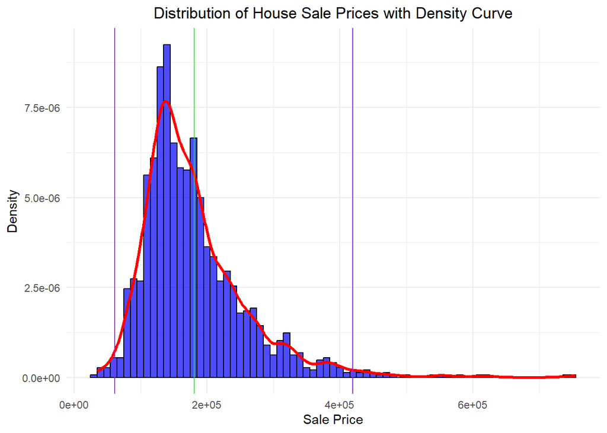

La prueba de Shapiro (la cual la podemos utilizar puesto nuestros datos no tienen más de 5000 observaciones) nos dice que:

```
##
##  Shapiro-Wilk normality test
##
## data:  training_data$SalePrice
## W = 0.86967, p-value < 2.2e-16
```

```
##
##  Asymptotic one-sample Kolmogorov-Smirnov test
##
## data:  training_data$SalePrice
## D = 0.12369, p-value < 2.2e-16
## alternative hypothesis: two-sided
```

### ¿Cuáles son los condominios con casas más caras/baratas?

Los condominios con las casa más caras son:

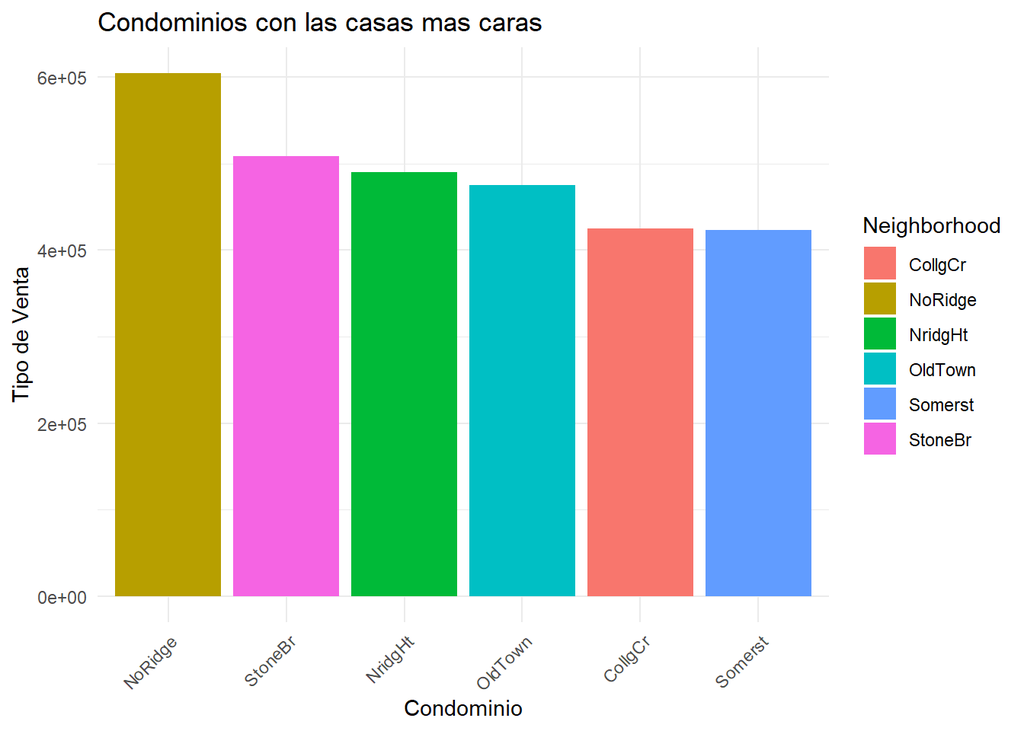

El gráfico de arriba nos muestra el promedio por condominio de SalesPrice de las casas cuyo precio es mayor a 3 veces la desviación estándar. Esto nos ayuda a determinar qué condominios son los que contienen las casas más caras.

Los condominios con casas más baratas son:

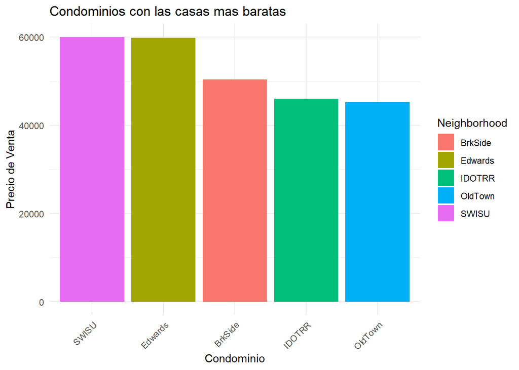

Este gráfico funcion de forma similar al anterior, muestra el promedio de SalePrice por condominio de todas las casas cuyo precio es menor o igual a 1.5 desviaciones estándar debajo de la media.

### ¿Cuál es la distribución de los tipos de ventas realizados?

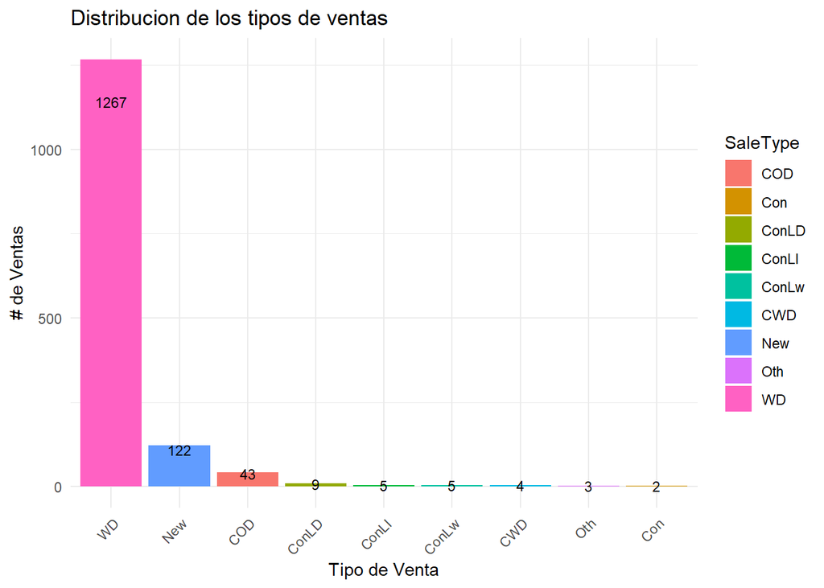

La gran mayoría de ventas son del tipo WD (Warranty Deed - Conventional) y por un gran márgen, para poder analizar mejor los datos podemos ver la distribución ignorando el tipo WD:

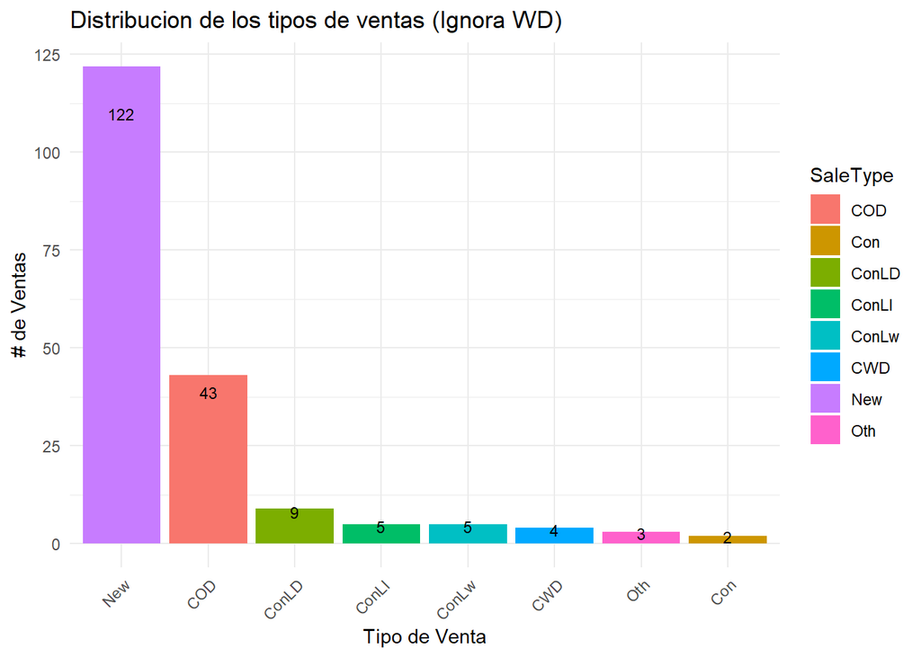

Dentro de los tipos de venta niche: ConLD, ConLI, ConLw, CWD, Oth y Con son masmoenos usadas en la misma frecuencia mientras que New (Home just constructed and sold) es usada con gran dominancia seguida en segundo lugar por COD (Court Officer Deed/Estate).

### ¿Cómo se compara el tamaño de la planta baja con el SalePrice?

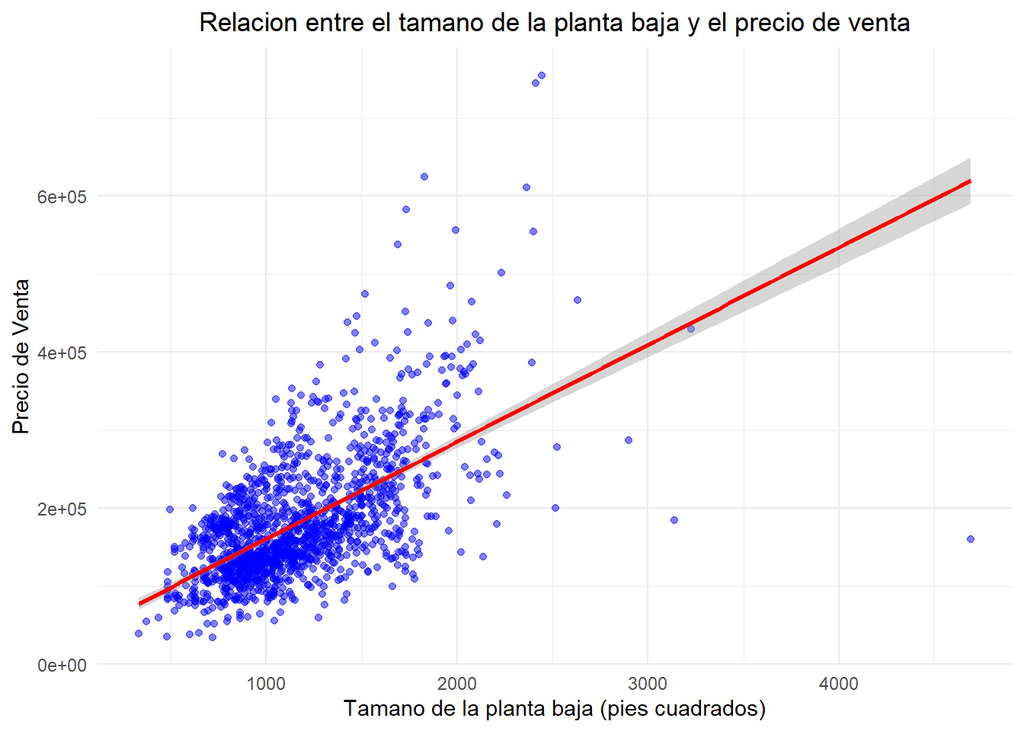

### ¿El tipo de fundación de la casa afecta su precio?

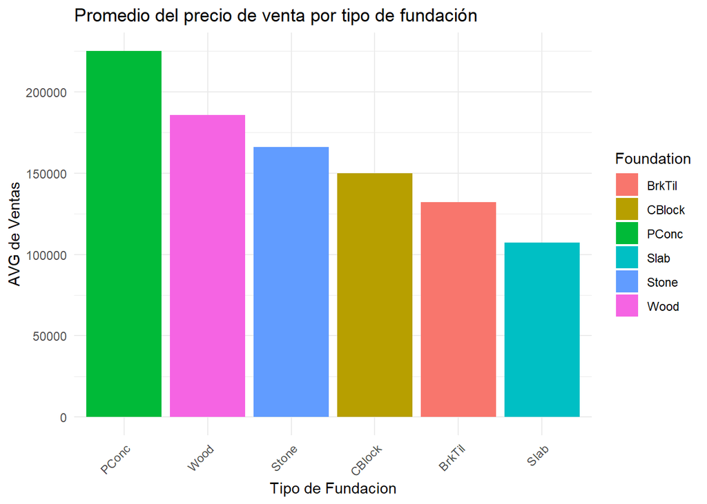

Como se puede ver por el diagrama, si hay una clara relación entre las construcciones realizadas por PConc y a tener un precio de venta más elevado en promedio lo que nos indica que esta variable pordría ser una muy buena predictora del precio de una casa.

### ¿Cuáles son las características más correlacionadas con el precio de venta?

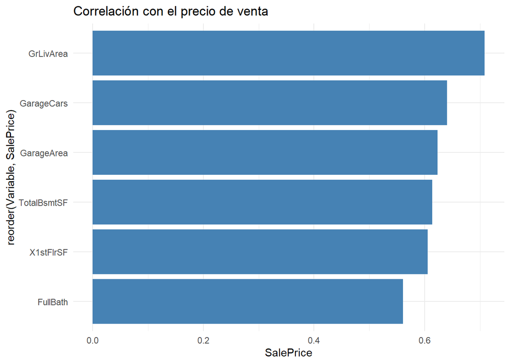

Se puede ver cuales son las variables que más se correlacionan con el precio de venta. Esto nos inidica cuales son las consideraciones a tomar en cuenta al momento de valuar una propiedad; aumentandolo o decreciendolo, según sea el caso.

### ¿Cómo varia el precio de venta según el vecindario?

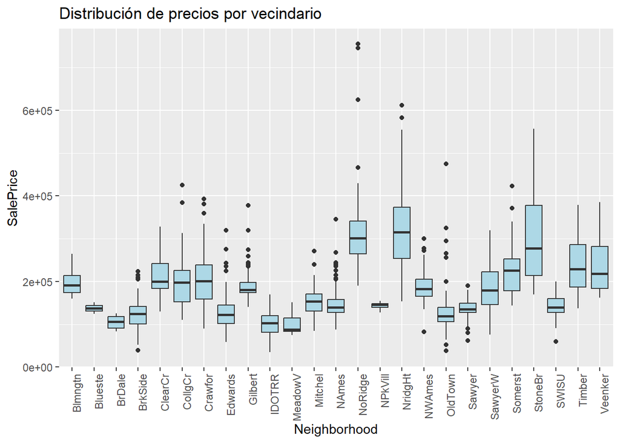

En el gráfico anterior podemos ver como se distribuye el precio de venta en cada condominio. Se puede ver que hay condominios que tienen una variedad de precios bastante limitada como en los condominios de Blueste o NPlVIII. La presencia de datos atípicos en algunos condominios nos puede indicar que existen casas en esos respectivos condominios que por ciertas razones estan valuadas mejor que el resto. Una mayor variedad de precios de venta indica que el condominio posee casas con distintas condiciones (variables listadas en la pregunta anterior) que hacen variar ese precio.

### ¿Cómo afecta la antigüedad de la vivienda a precio de venta?

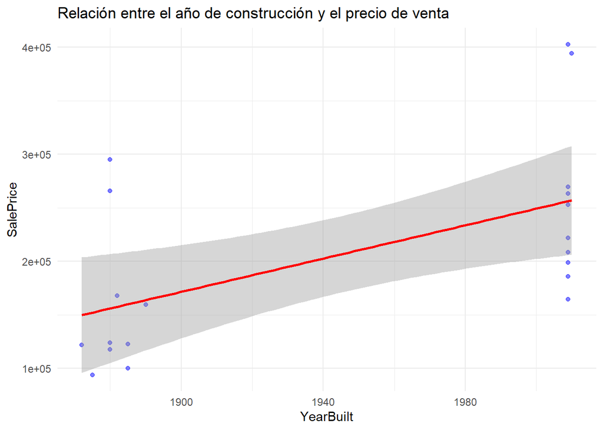

### ¿Existen patrones estacionales en las ventas de propiedades?

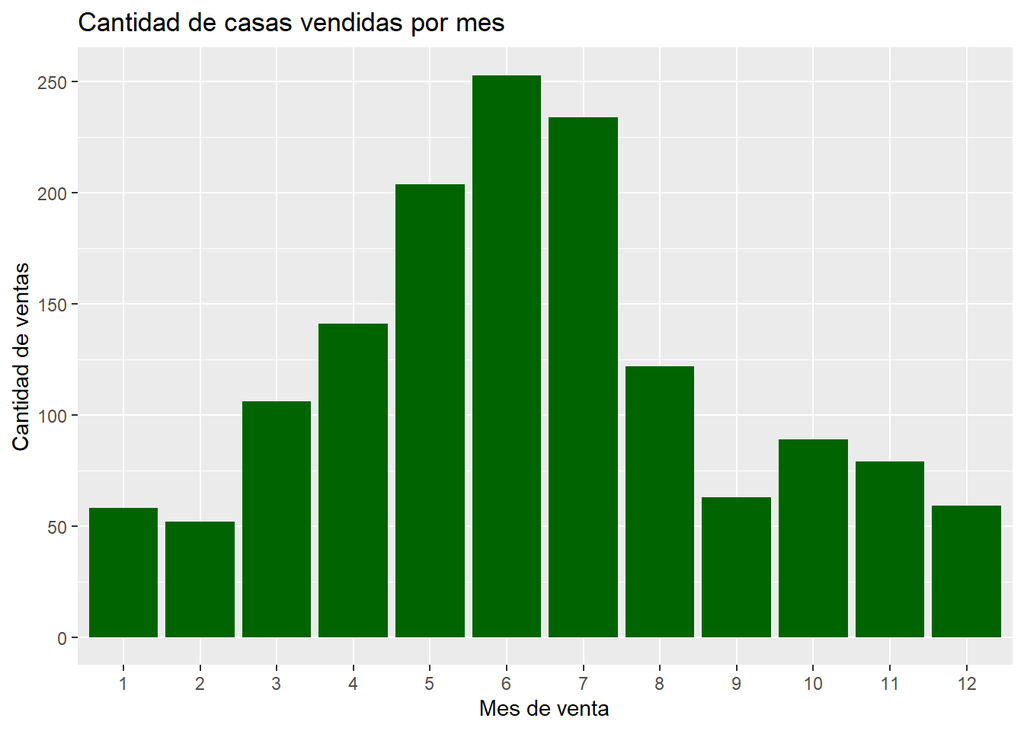

Según se puede ver en la distribución de la cantidad de casas vendidas por mes, se puede ver que la mayor cantidad de casas se vende a lo largo de la mitad del año: Mayo, Junio y Julio. Indicando esto como los mejores meses para poder vender casas.

### ¿Cómo varian las calificaciones de calidad y condición según el tipo de fachada y su material?

```
## # A tibble: 37 × 4
##    Exterior1st ExterQual mean_overallqual mean_overallcond
##    <fct>       <fct>                <dbl>            <dbl>
##  1 AsbShng     Fa                    2                3
##  2 AsbShng     TA                    4.63             5.26
##  3 AsphShn     TA                    5                5
##  4 BrkComm     TA                    4                3
##  5 BrkFace     Gd                    7.33             5.83
##  6 BrkFace     TA                    5.47             5.61
##  7 CBlock      Fa                    4                6
##  8 CemntBd     Ex                    8.8              5.53
##  9 CemntBd     Gd                    7.73             5.23
## 10 CemntBd     TA                    4.83             5.92
## # ℹ 27 more rows
```

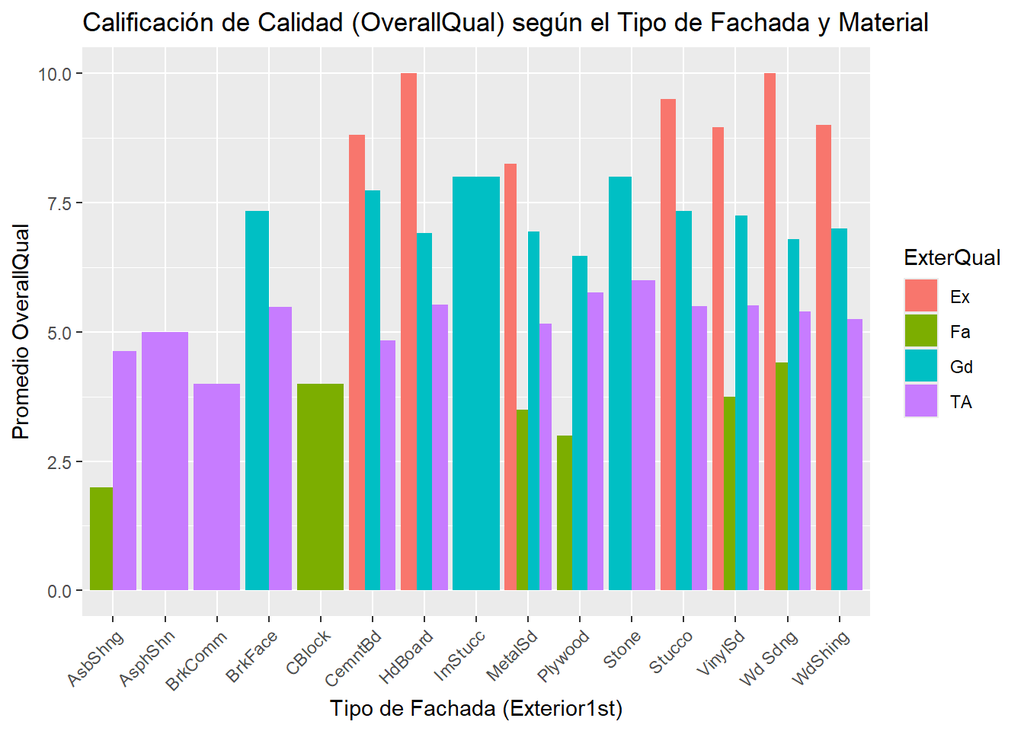

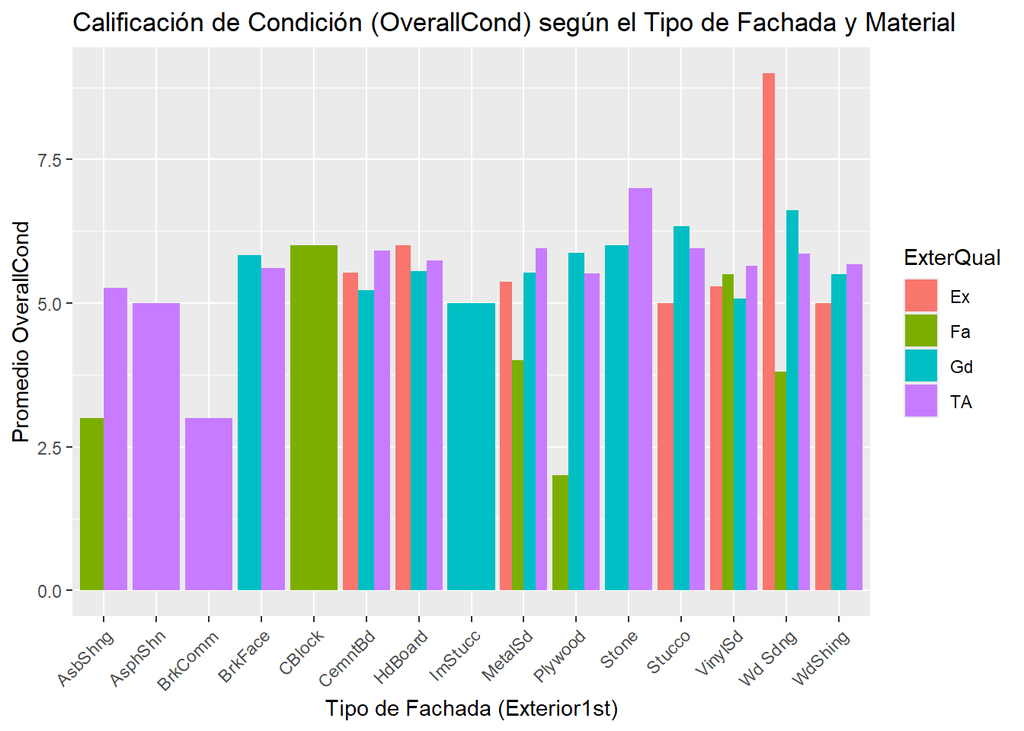

Se tiene las siguientes clasificaciones para ExterQual: Ex (Excelente, el material es de alta gama), Fa (Justo, la calidad del material es bastante baja), Gd (Bueno, la calidad del material es buena) y TA (Típico/Promedio, el material tiene una condición funcional pero no excepcional). Haciendo un análisis rápido se puede ver que la fachada que presenta las mejores condiciones con respecto a calidad y condición es la “Wd Sdng”, se puede ver que existen fachadas que se ven perjudicadas a pesar de usar materiales de alta calidad, inidicando que estas fachadas es mejor abaratar sus costos y hacerlas con materiales que tengan una mejor duración ante la calidad.

### Análisis Exploratorio por Grupos

Con respecto a las variables cuantitativas, solo se va a hacer la omisión de **GarageYrBlt**, debido a que el año en que se construyó el garaje no aporta mucha información al agrupamiento de los datos.

De igual forma, los valores identificados como `NA` se reescribieron como **0**, debido a que este era el valor que representaba ese tipo de datos en las columnas respectivas donde aparecía.

Al final estas son las variables a analizar durante el agrupamiento: **Id, MSSubClass, LotFrontage, LotArea, OverallQual, OverallCond, YearBuilt, YearRemodAdd, MasVnrArea, BsmtFinSF1, BsmtFinSF2, BsmtUnfSF, TotalBsmtSF, X1stFlrSF, X2ndFlrSF, LowQualFinSF, GrLivArea, BsmtFullBath, BsmtHalfBath, FullBath, HalfBath, BedroomAbvGr, KitchenAbvGr, TotRmsAbvGrd, Fireplaces, GarageCars, GarageArea, WoodDeckSF, OpenPorchSF, EnclosedPorch, X3SsnPorch, ScreenPorch, PoolArea, MiscVal, MoSold, YrSold, SalePrice**.

Para determinar si existe una relación entre nuestras variables calculamos el estadístico de Hopkins.

```
## Estadistico de Hopkins:  1
```

Al obtener 1 como valor de Hopkins, esto demuestra que nuestros datos tiene una fuerte estructura de agrupamiento. Ahora se va a determinar la cantidad óptima de grupos para hacer el agrupamiento.

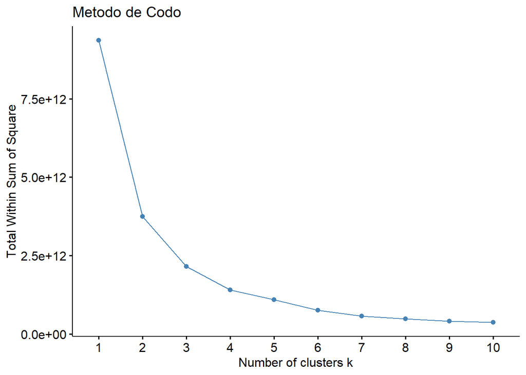

Viendo el gráfico de codo se refleja que el número óptimo de grupos es de 3. Para el agrupamiento de los datos se va a utilizar K-means. Utilizando K-means obtenemos los siguientes resultados del agrupamiento:

```
##   Group.1       Id MSSubClass LotFrontage   LotArea OverallQual OverallCond
## 1       1 738.4169   59.29901    53.94789  8731.475    5.254342    5.703474
## 2       2 734.6505   55.64486    58.11776 11867.650    6.844860    5.435514
## 3       3 658.2185   46.26050    80.29412 16536.193    8.470588    5.336134
##   YearBuilt YearRemodAdd MasVnrArea BsmtFinSF1 BsmtFinSF2 BsmtUnfSF TotalBsmtSF
## 1  1955.872     1974.983   56.47395   358.5509   49.75558  469.9553    878.2618
## 2  1988.925     1995.744  120.70654   466.1738   46.29159  679.4579   1191.9234
## 3  1996.160     2002.899  339.95798   918.6471   25.99160  721.6555   1666.2941
##   X1stFlrSF X2ndFlrSF LowQualFinSF GrLivArea BsmtFullBath BsmtHalfBath FullBath
## 1  1010.988  227.5112     6.667494  1245.166    0.3598015   0.06575682 1.260546
## 2  1270.095  469.0000     4.835514  1743.931    0.4523364   0.05046729 1.906542
## 3  1706.538  607.7311     4.806723  2319.076    0.7478992   0.03361345 2.092437
##    HalfBath BedroomAbvGr KitchenAbvGr TotRmsAbvGrd Fireplaces GarageCars
## 1 0.2531017     2.767990     1.076923     5.901985  0.3920596   1.394541
## 2 0.5308411     2.975701     1.011215     7.013084  0.8093458   2.106542
## 3 0.5966387     3.042017     1.000000     8.462185  1.2268908   2.764706
##   GarageArea WoodDeckSF OpenPorchSF EnclosedPorch X3SsnPorch ScreenPorch
## 1   375.6725   64.53474    28.63400     29.028536   1.514888    12.02978
## 2   554.3981  116.43738    64.57196     14.201869   5.854206    18.60000
## 3   766.0168  195.69748    88.22689      8.890756   5.252101    19.68067
##   PoolArea  MiscVal   MoSold   YrSold SalePrice
## 1 1.310174 53.73945 6.172457 2007.836  129374.1
## 2 4.517757 37.71963 6.476636 2007.789  215791.3
## 3 4.663866  0.00000 6.638655 2007.798  373286.7
```

Se puede ver que cada clusters representa lo siguiente: las propiedades de menor tamaño, calidad y precio (grupo 1); las propiedades de tamaño y calidad medios, con precios intermedios (grupo 2); y las propiedades de mayor tamaño, calidad y precio (grupo 3). Este agrupamiento indica un comportamiento esperable en el que el grupo 3 tiene las variables con los valores más altos, al ser las propiedades con mejor calidad y precio. Esto implica que la utilización de una mayor cantidad de recursos hace que aumente tanto el valor de la propiedad como de su calidad. Las variables que más terminan influyendo en esta separación por grupos temrinan siendo aquellas relacionadas con el tamaño y la calidad de la propiedad.

## Ingeniería de Características

Como se pudo ver por el análisis exploratorio realizado con anterioridad salieron varios candidatos para predecir el precio de una casa, sin embargo, una de las variables que tuvo una fuerte correlación con el precio fue el tipo de fundación de la casa, ya que de forma muy consisntente las casas con una fundación PConc (Poured Concrete) tienen un precio más elevado comparado con las Slab o incluso las BrkTil (Brick and Tile).

## Modelos

```
##
## Call:
## lm(formula = SalePrice ~ GrLivArea, data = training_data)
##
## Residuals:
##     Min      1Q  Median      3Q     Max
## -462999  -29800   -1124   21957  339832
##
## Coefficients:
##              Estimate Std. Error t value Pr(>|t|)
## (Intercept) 18569.026   4480.755   4.144 3.61e-05 ***
## GrLivArea     107.130      2.794  38.348  < 2e-16 ***
## ---
## Signif. codes:  0 '***' 0.001 '**' 0.01 '*' 0.05 '.' 0.1 ' ' 1
##
## Residual standard error: 56070 on 1458 degrees of freedom
## Multiple R-squared:  0.5021, Adjusted R-squared:  0.5018
## F-statistic:  1471 on 1 and 1458 DF,  p-value: < 2.2e-16
```

[figure not shown]

Aunque el p-value es mucho menor a 0.05 sabemos que esto no es suficiente puesto que en promedio según el Error estándar residual nuestro modelo se equivoca por $56,070 mas o menos.

## Regresión para variables numéricas

En este caso la regresión de las variables se va a realizar con las variables cuantitaticas; omitiendo todas la variables cualitativas, aunque tengan una representación numérica. De esta forma obtendremos una regresión lineal lo suficientemente precisa para predecir el precio de las casas.

```
##
## Call:
## lm(formula = SalePrice ~ ., data = num_vars)
##
## Residuals:
##     Min      1Q  Median      3Q     Max
## -535822  -17277   -2113   15927  309148
##
## Coefficients:
##                 Estimate Std. Error t value Pr(>|t|)
## (Intercept)   -7.413e+05  1.534e+06  -0.483 0.628923
## LotFrontage    5.735e+01  3.067e+01   1.870 0.061683 .
## LotArea        3.007e-01  1.086e-01   2.768 0.005719 **
## YearBuilt      3.582e+02  5.743e+01   6.238 5.83e-10 ***
## YearRemodAdd   4.384e+02  6.494e+01   6.751 2.13e-11 ***
## MasVnrArea     3.463e+01  6.446e+00   5.372 9.09e-08 ***
## BsmtFinSF1     3.019e+01  5.021e+00   6.013 2.31e-09 ***
## BsmtFinSF2     1.800e+01  7.659e+00   2.350 0.018925 *
## BsmtUnfSF      2.219e+01  4.441e+00   4.996 6.56e-07 ***
## X1stFlrSF      5.437e+01  6.232e+00   8.724  < 2e-16 ***
## X2ndFlrSF      5.516e+01  5.144e+00  10.724  < 2e-16 ***
## LowQualFinSF   1.422e+01  2.140e+01   0.664 0.506544
## BsmtFullBath   6.725e+03  2.832e+03   2.375 0.017675 *
## BsmtHalfBath   1.095e+03  4.427e+03   0.247 0.804682
## FullBath       4.339e+03  3.055e+03   1.420 0.155738
## HalfBath      -2.773e+03  2.896e+03  -0.958 0.338393
## BedroomAbvGr  -1.193e+04  1.794e+03  -6.653 4.07e-11 ***
## KitchenAbvGr  -4.277e+04  5.214e+03  -8.202 5.21e-16 ***
## TotRmsAbvGrd   6.876e+03  1.336e+03   5.147 3.02e-07 ***
## Fireplaces     7.811e+03  1.910e+03   4.090 4.55e-05 ***
## GarageYrBlt   -1.202e+01  2.922e+00  -4.115 4.09e-05 ***
## GarageCars     1.831e+04  3.235e+03   5.661 1.82e-08 ***
## GarageArea     9.498e+00  1.062e+01   0.894 0.371334
## WoodDeckSF     2.713e+01  8.676e+00   3.128 0.001798 **
## OpenPorchSF    4.840e+00  1.650e+01   0.293 0.769327
## EnclosedPorch  2.539e+01  1.814e+01   1.400 0.161878
## X3SsnPorch     2.713e+01  3.408e+01   0.796 0.426124
## ScreenPorch    6.649e+01  1.868e+01   3.560 0.000382 ***
## PoolArea      -4.579e+01  2.575e+01  -1.778 0.075560 .
## MiscVal        5.198e-01  2.017e+00   0.258 0.796673
## MoSold         3.622e+02  3.738e+02   0.969 0.332652
## YrSold        -3.853e+02  7.629e+02  -0.505 0.613554
## ---
## Signif. codes:  0 '***' 0.001 '**' 0.01 '*' 0.05 '.' 0.1 ' ' 1
##
## Residual standard error: 37790 on 1428 degrees of freedom
## Multiple R-squared:  0.7785, Adjusted R-squared:  0.7737
## F-statistic: 161.9 on 31 and 1428 DF,  p-value: < 2.2e-16
```

En el resumen del modelo realizado se puede ver que la distribución de los residuos presenta un rango amplio (-535822 a 309148), esto indica que el modelo puede tener dificultades para predecir algunos valores extremos. Estos valores de máximo y mínimo implica la presencia de datos atípicos, que es lo que hace que el modelo no prediga a la perfección datos extremos.

Viendo a profuncdidad las métricas podemos encontrar lo siguiente. El R-cuadrado es 0.7785, significando que el modelo explica aproximadamente el 77.85% de la variabilidad en el precio de venta. Viendo que el R-cuadrado ajustado es ligeramente menor al R-cuadrado, demuestra que hay variables incluidas en el modelo que no estan contribuyendo a la predicción.

Para ver de forma gráfica el modelo de regresión, se hace el gráfico de dispersión entre cada una de las variables predictoras y el precio de venta. A continuación se muestra la relación de las variables significativas encontradas:

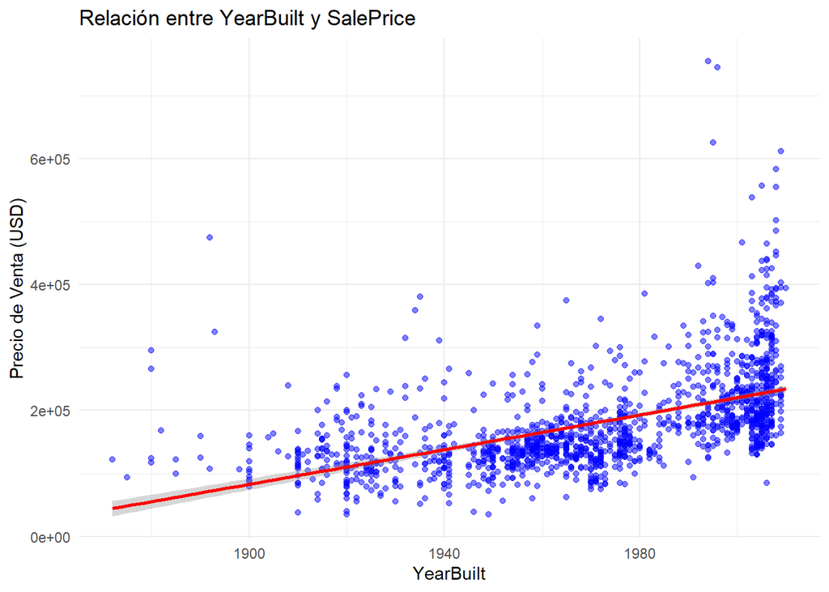

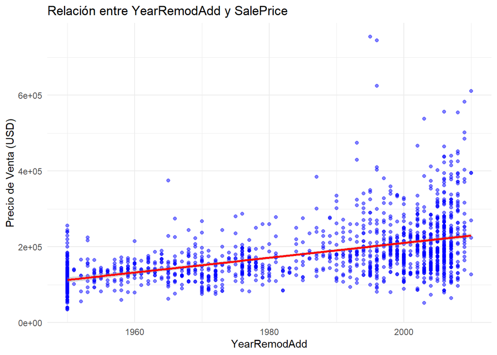

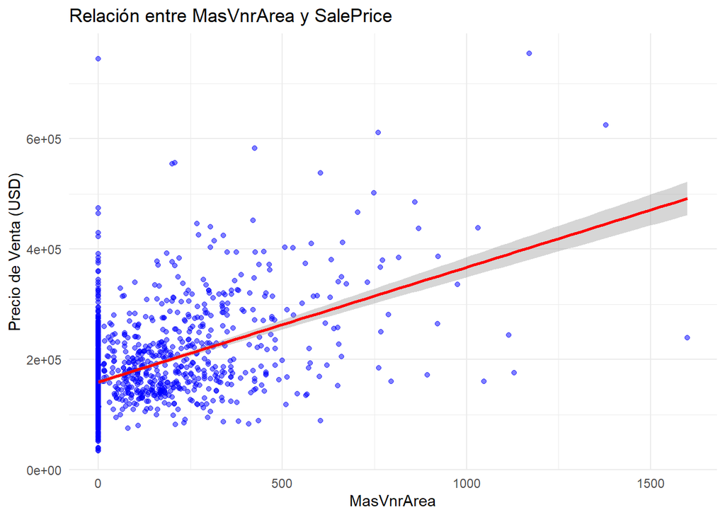

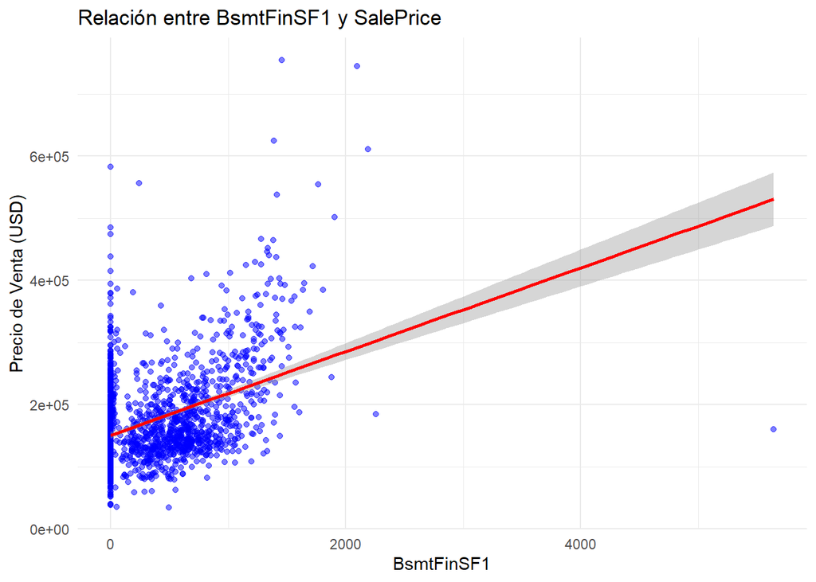

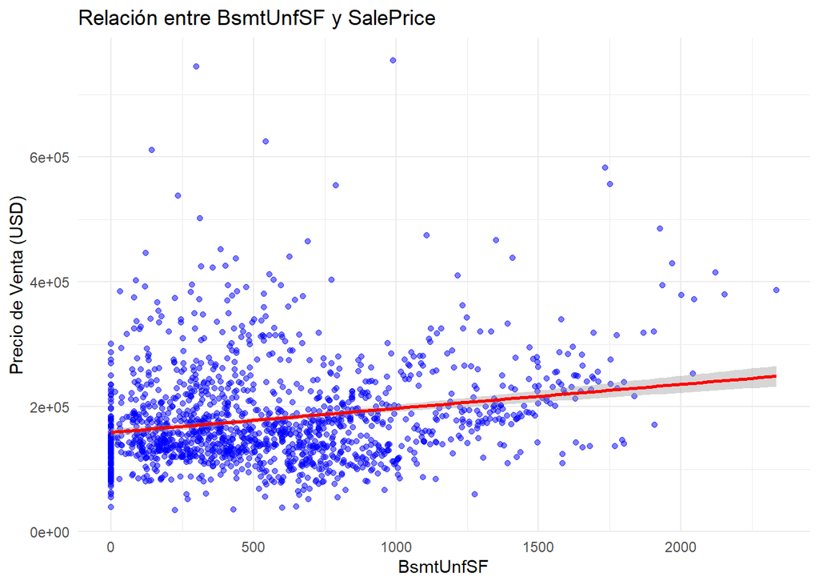

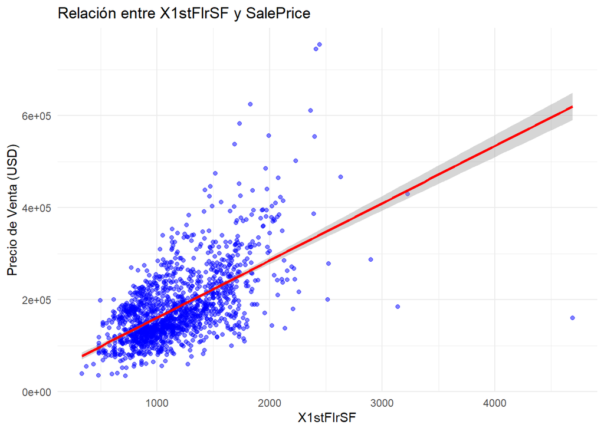

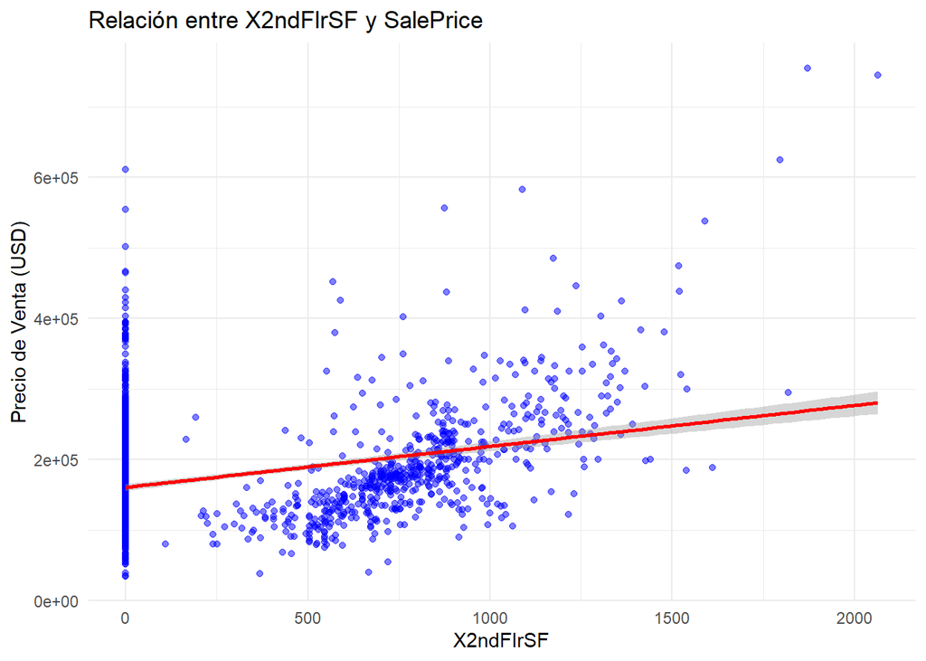

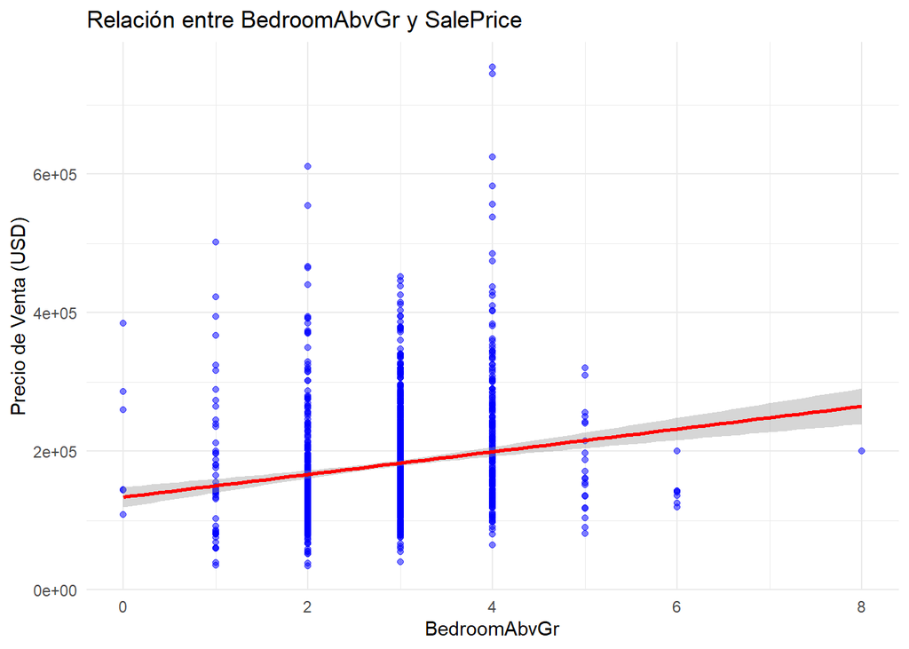

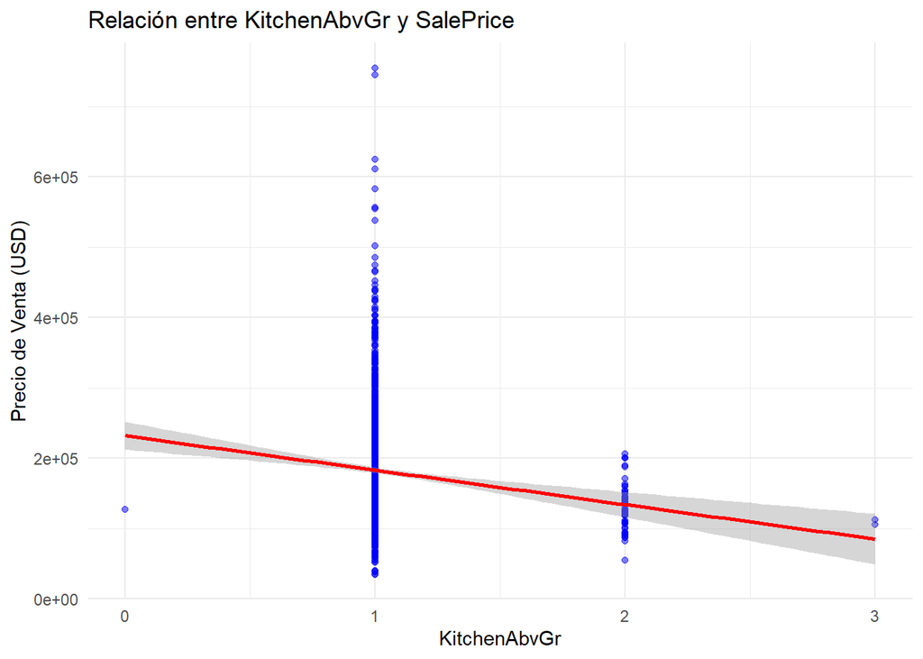

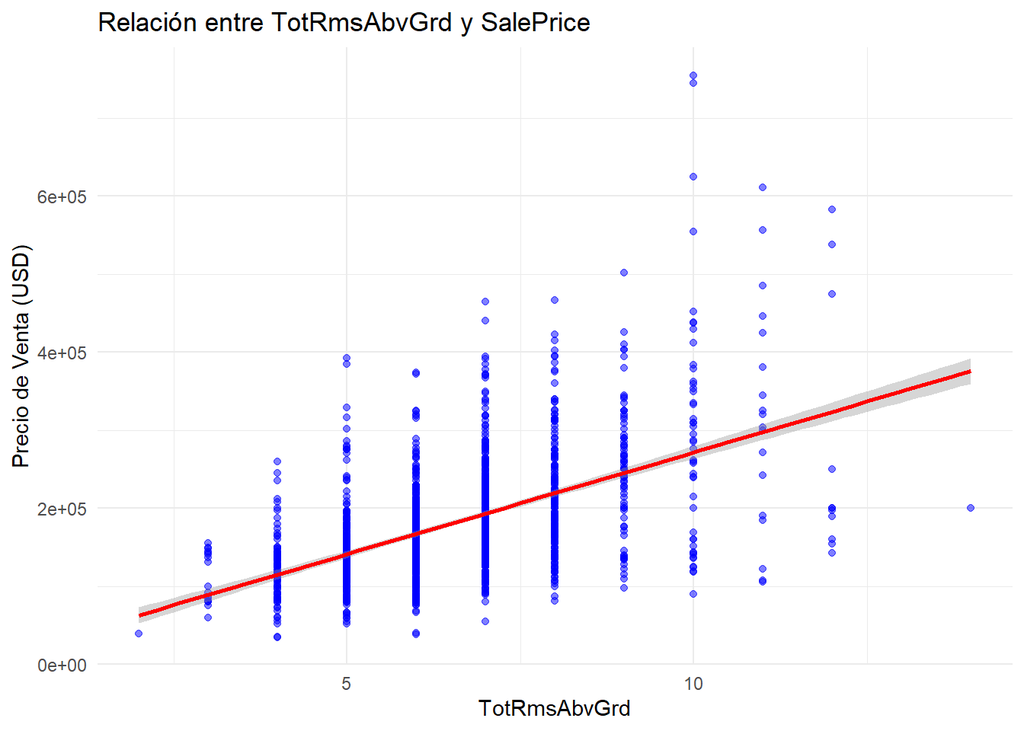

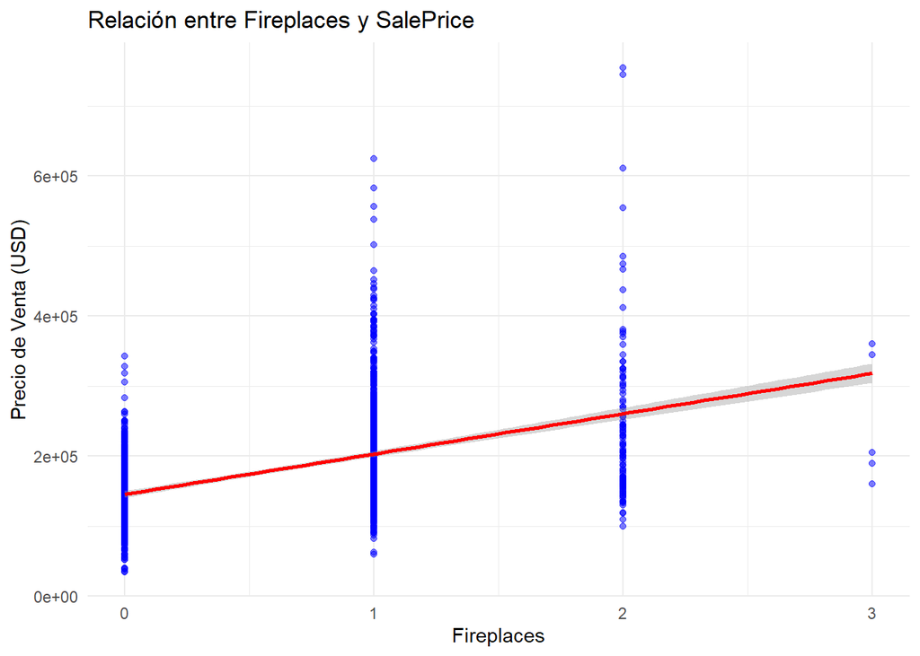

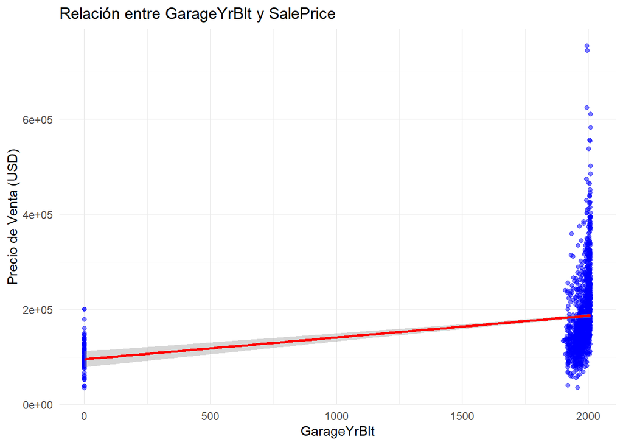

[3 more figures not shown]

### Multicolinealidad entre variables

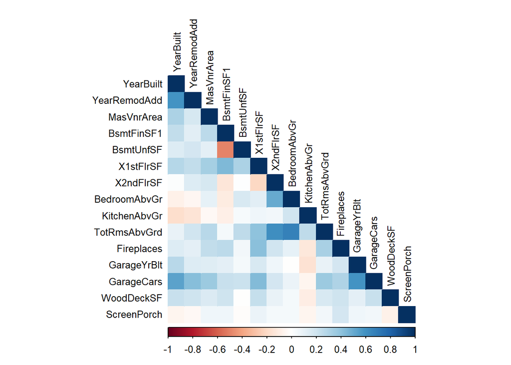

Analizando el gráifco de correlación se puede busca aquellas variables en donde se encuentre una fuerte intensidad de color azul. Bajo este criterio se tiene multicolinealidad entre las sigueinte variables.

**YearBuilt y YearRemoveAdd**: Existe correlación entre estas variables debido a que mientras más antigua sea la casa, más probable es que se hayan hecho remodelaciones en esta.

### Identificación de variables de mayor impacto

```
##                LotFrontage      LotArea    YearBuilt YearRemodAdd   MasVnrArea
## LotFrontage    1.000000000  0.100738810  0.036853429  0.078685515  0.105009833
## LotArea        0.100738810  1.000000000  0.014227652  0.013788427  0.103320506
## YearBuilt      0.036853429  0.014227652  1.000000000  0.592854976  0.311600107
## YearRemodAdd   0.078685515  0.013788427  0.592854976  1.000000000  0.176529181
## MasVnrArea     0.105009833  0.103320506  0.311600107  0.176529181  1.000000000
## BsmtFinSF1     0.076669997  0.214103131  0.249503197  0.128450547  0.261256055
## BsmtFinSF2    -0.009312309  0.111169745 -0.049106831 -0.067758514 -0.071329628
## BsmtUnfSF      0.160829277 -0.002618360  0.149040392  0.181133087  0.113862163
## X1stFlrSF      0.245180931  0.299474579  0.281985859  0.240379268  0.339850414
## X2ndFlrSF      0.042549244  0.050985948  0.010307660  0.140023779  0.173800000
## LowQualFinSF   0.049981430  0.004778970 -0.183784344 -0.062419100 -0.068627980
## BsmtFullBath   0.010514333  0.158154531  0.187598550  0.119469879  0.083010048
## BsmtHalfBath  -0.027855658  0.048045571 -0.038161806 -0.012337032  0.027402662
## FullBath       0.120547870  0.126030627  0.468270787  0.439046484  0.272998856
## HalfBath      -0.012952103  0.014259469  0.242655910  0.183330612  0.199107519
## BedroomAbvGr   0.144493646  0.119689908 -0.070651217 -0.040580928  0.102774516
## KitchenAbvGr   0.034424658 -0.017783871 -0.174800246 -0.149597521 -0.038450112
## TotRmsAbvGrd   0.221396241  0.190014778  0.095589128  0.191739816  0.279567888
## Fireplaces     0.044017642  0.271364010  0.147716399  0.112581318  0.247015277
## GarageYrBlt    0.019316523  0.072598768  0.272029321  0.146357224  0.132696387
## GarageCars     0.165228607  0.154870740  0.537850092  0.420622155  0.361944566
## GarageArea     0.201473353  0.180402755  0.478953820  0.371599809  0.370884153
## WoodDeckSF    -0.016779759  0.171697687  0.224880142  0.205725920  0.159990530
## OpenPorchSF    0.069604952  0.084773809  0.188685840  0.226297633  0.122528332
## EnclosedPorch  0.027366105 -0.018339734 -0.387267783 -0.193919147 -0.109906797
## X3SsnPorch     0.023498724  0.020422830  0.031354513  0.045285810  0.019143784
## ScreenPorch    0.022968732  0.043160378 -0.050364435 -0.038740011  0.062247711
## PoolArea       0.114106359  0.077672392  0.004949728  0.005829372  0.011928394
## MiscVal       -0.059605730  0.038067692 -0.034383139 -0.010286249 -0.029512249
## MoSold         0.018941943  0.001204988  0.012398471  0.021490002 -0.006723204
## YrSold        -0.012093960 -0.014261407 -0.013617680  0.035743247 -0.008316623
## SalePrice      0.209623945  0.263843354  0.522897333  0.507100967  0.472614499
##                 BsmtFinSF1   BsmtFinSF2    BsmtUnfSF    X1stFlrSF    X2ndFlrSF
## LotFrontage    0.076669997 -0.009312309  0.160829277  0.245180931  0.042549244
## LotArea        0.214103131  0.111169745 -0.002618360  0.299474579  0.050985948
## YearBuilt      0.249503197 -0.049106831  0.149040392  0.281985859  0.010307660
## YearRemodAdd   0.128450547 -0.067758514  0.181133087  0.240379268  0.140023779
## MasVnrArea     0.261256055 -0.071329628  0.113862163  0.339850414  0.173800000
## BsmtFinSF1     1.000000000 -0.050117400 -0.495251469  0.445862656 -0.137078986
```

[output cut: 176 more lines]

```
## TotRmsAbvGrd   0.0247628842  0.036907077 -0.034516354  0.53372316
## Fireplaces     0.0014086054  0.046357102 -0.024095565  0.46692884
## GarageYrBlt   -0.0066692852  0.019150855 -0.011133813  0.26136644
## GarageCars    -0.0430801281  0.040521730 -0.039116904  0.64040920
## GarageArea    -0.0273999144  0.027973800 -0.027377940  0.62343144
## WoodDeckSF    -0.0095512282  0.021011044  0.022270451  0.32441344
## OpenPorchSF   -0.0185837390  0.071254885 -0.057619360  0.31585623
## EnclosedPorch  0.0183606001 -0.028887266 -0.009915937 -0.12857796
## X3SsnPorch     0.0003539653  0.029473795  0.018644925  0.04458367
## ScreenPorch    0.0319457608  0.023216992  0.010694106  0.11144657
## PoolArea       0.0296686509 -0.033736640 -0.059688932  0.09240355
## MiscVal        1.0000000000 -0.006494550  0.004906262 -0.02118958
## MoSold        -0.0064945502  1.000000000 -0.145721413  0.04643225
## YrSold         0.0049062625 -0.145721413  1.000000000 -0.02892259
## SalePrice     -0.0211895796  0.046432245 -0.028922585  1.00000000
```

- YearBuilt (0.52): El año de construcción de la casa tiene una correlación positiva moderada. Esto sugiere que las casas más nuevas tienden a tener precios más altos.
- YearRemodAdd (0.51): El año de la última remodelación también tiene una correlación positiva moderada. Esto indica que las casas remodeladas recientemente tienden a tener precios más altos.
- MasVnrArea (0.47): El área de revestimiento de mampostería tiene una correlación positiva moderada. Esto sugiere que las casas con más revestimiento de mampostería tienden a tener precios más altos.
- BsmtFinSF1 (0.39): El área de pies cuadrados terminados del sótano de tipo 1 tiene una correlación positiva moderada. Esto indica que los sótanos terminados contribuyen al precio de la casa.
- X1stFlrSF (0.61): El área de pies cuadrados del primer piso tiene una correlación positiva fuerte. Esto es lógico, ya que un área de primer piso más grande generalmente significa una casa más grande y, por lo tanto, más cara.
- FullBath (0.56): El número de baños completos tiene una correlación positiva moderada. Más baños completos generalmente aumentan el precio de la casa.
- TotRmsAbvGrd (0.53): El número total de habitaciones sobre el nivel del suelo tiene una correlación positiva moderada. Más habitaciones generalmente significan una casa más grande y, por lo tanto, más cara.
- Fireplaces (0.47): El número de chimeneas tiene una correlación positiva moderada. Las chimeneas son una característica deseable que puede aumentar el precio de la casa.
- GarageCars (0.64): El tamaño del garaje en capacidad de automóviles tiene una correlación positiva fuerte. Un garaje más grande generalmente aumenta el precio de la casa.
- GarageArea (0.62): El tamaño del garaje en área tiene una correlación positiva fuerte. Similar a GarageCars, un garaje más grande aumenta el precio.
- WoodDeckSF (0.32): El área de la terraza de madera tiene una correlación positiva moderada. Las terrazas de madera son una característica deseable que puede aumentar el precio.
- OpenPorchSF (0.32): El área del porche abierto tiene una correlación positiva moderada. Similar a la terraza de madera, un porche abierto es una característica deseable.

Habiendo analizado la relación entre variables anteriormente se van a omitir las variables **GarageCars** y **YearRemodAdd**, debido a que estan altamente correlacionadas con **GarageArea** y **YearBuilt** respectivamente.

### Identificar sobreajuste

```
##
## Call:
## lm(formula = SalePrice ~ ., data = num_vars)
##
## Residuals:
##     Min      1Q  Median      3Q     Max
## -535822  -17277   -2113   15927  309148
##
## Coefficients:
##                 Estimate Std. Error t value Pr(>|t|)
## (Intercept)   -7.413e+05  1.534e+06  -0.483 0.628923
## LotFrontage    5.735e+01  3.067e+01   1.870 0.061683 .
## LotArea        3.007e-01  1.086e-01   2.768 0.005719 **
## YearBuilt      3.582e+02  5.743e+01   6.238 5.83e-10 ***
## YearRemodAdd   4.384e+02  6.494e+01   6.751 2.13e-11 ***
## MasVnrArea     3.463e+01  6.446e+00   5.372 9.09e-08 ***
## BsmtFinSF1     3.019e+01  5.021e+00   6.013 2.31e-09 ***
## BsmtFinSF2     1.800e+01  7.659e+00   2.350 0.018925 *
## BsmtUnfSF      2.219e+01  4.441e+00   4.996 6.56e-07 ***
## X1stFlrSF      5.437e+01  6.232e+00   8.724  < 2e-16 ***
## X2ndFlrSF      5.516e+01  5.144e+00  10.724  < 2e-16 ***
## LowQualFinSF   1.422e+01  2.140e+01   0.664 0.506544
## BsmtFullBath   6.725e+03  2.832e+03   2.375 0.017675 *
## BsmtHalfBath   1.095e+03  4.427e+03   0.247 0.804682
## FullBath       4.339e+03  3.055e+03   1.420 0.155738
## HalfBath      -2.773e+03  2.896e+03  -0.958 0.338393
## BedroomAbvGr  -1.193e+04  1.794e+03  -6.653 4.07e-11 ***
## KitchenAbvGr  -4.277e+04  5.214e+03  -8.202 5.21e-16 ***
## TotRmsAbvGrd   6.876e+03  1.336e+03   5.147 3.02e-07 ***
## Fireplaces     7.811e+03  1.910e+03   4.090 4.55e-05 ***
## GarageYrBlt   -1.202e+01  2.922e+00  -4.115 4.09e-05 ***
## GarageCars     1.831e+04  3.235e+03   5.661 1.82e-08 ***
## GarageArea     9.498e+00  1.062e+01   0.894 0.371334
## WoodDeckSF     2.713e+01  8.676e+00   3.128 0.001798 **
## OpenPorchSF    4.840e+00  1.650e+01   0.293 0.769327
## EnclosedPorch  2.539e+01  1.814e+01   1.400 0.161878
## X3SsnPorch     2.713e+01  3.408e+01   0.796 0.426124
## ScreenPorch    6.649e+01  1.868e+01   3.560 0.000382 ***
## PoolArea      -4.579e+01  2.575e+01  -1.778 0.075560 .
## MiscVal        5.198e-01  2.017e+00   0.258 0.796673
## MoSold         3.622e+02  3.738e+02   0.969 0.332652
## YrSold        -3.853e+02  7.629e+02  -0.505 0.613554
## ---
## Signif. codes:  0 '***' 0.001 '**' 0.01 '*' 0.05 '.' 0.1 ' ' 1
##
## Residual standard error: 37790 on 1428 degrees of freedom
## Multiple R-squared:  0.7785, Adjusted R-squared:  0.7737
## F-statistic: 161.9 on 31 and 1428 DF,  p-value: < 2.2e-16
```

Para identificar si el modelo esta sobreajustado, se puede demostrar comparando los valores de R^2 y R^2 ajustado. En este caso se que ve que estos valores no presentan una diferencia significativa entre sí, indicanco que el modelo no se encuentra sobre ajustado.

### Nuevo modelo

```
##
## Call:
## lm(formula = SalePrice ~ ., data = num_vars)
##
## Residuals:
##     Min      1Q  Median      3Q     Max
## -479296  -21755   -2134   17636  373149
##
## Coefficients:
##                Estimate Std. Error t value Pr(>|t|)
## (Intercept)  -1.094e+06  9.657e+04 -11.330  < 2e-16 ***
## YearBuilt     5.481e+02  4.961e+01  11.049  < 2e-16 ***
## MasVnrArea    5.001e+01  7.184e+00   6.961 5.10e-12 ***
## BsmtFinSF1    1.864e+01  2.971e+00   6.272 4.69e-10 ***
## X1stFlrSF     3.027e+01  4.008e+00   7.552 7.53e-14 ***
## FullBath      1.510e+04  2.939e+03   5.137 3.18e-07 ***
## TotRmsAbvGrd  1.075e+04  9.492e+02  11.324  < 2e-16 ***
## Fireplaces    1.801e+04  2.016e+03   8.933  < 2e-16 ***
## GarageArea    7.042e+01  6.977e+00  10.093  < 2e-16 ***
## WoodDeckSF    4.498e+01  9.670e+00   4.651 3.60e-06 ***
## OpenPorchSF   7.921e+01  1.828e+01   4.334 1.57e-05 ***
## ---
## Signif. codes:  0 '***' 0.001 '**' 0.01 '*' 0.05 '.' 0.1 ' ' 1
##
## Residual standard error: 43690 on 1449 degrees of freedom
## Multiple R-squared:  0.6997, Adjusted R-squared:  0.6976
## F-statistic: 337.6 on 10 and 1449 DF,  p-value: < 2.2e-16
```

Los residuos del modelo muestran una alta dispersión, con errores que varían desde -479296 hasta 373149, lo que indica que el modelo no es igualmente preciso para todas las predicciones. Aunque la mediana de los residuos está cerca de cero (-2134), lo que sugiere poco sesgo general, la amplia dispersión y la presencia de valores atípicos (outliers) indican que el modelo tiene margen de mejora.

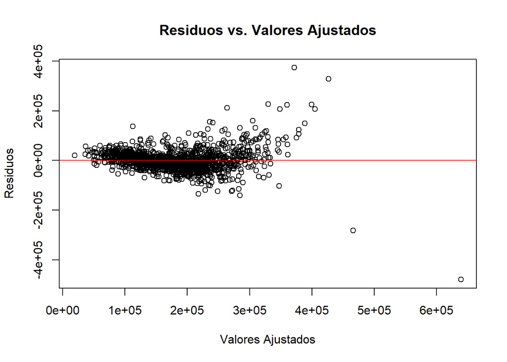

El gráfico muestra que los errores del modelo se distribuyen bastante bien alrededor de cero, lo que sugiere que el modelo generalmente hace predicciones equilibradas. Sin embargo, los errores tienden a dispersarse más a medida que las predicciones del modelo aumentan, lo que indica que el modelo podría ser menos preciso para las predicciones más altas. Además, hay algunos errores muy grandes, tanto positivos como negativos, lo que sugiere que el modelo tiene dificultades para predecir con precisión algunos valores extremos.

## Comparativa de los modelos

```
##
## Call:
## lm(formula = SalePrice ~ GrLivArea, data = training_data)
##
## Residuals:
##     Min      1Q  Median      3Q     Max
## -462999  -29800   -1124   21957  339832
##
## Coefficients:
##              Estimate Std. Error t value Pr(>|t|)
## (Intercept) 18569.026   4480.755   4.144 3.61e-05 ***
## GrLivArea     107.130      2.794  38.348  < 2e-16 ***
## ---
## Signif. codes:  0 '***' 0.001 '**' 0.01 '*' 0.05 '.' 0.1 ' ' 1
##
## Residual standard error: 56070 on 1458 degrees of freedom
## Multiple R-squared:  0.5021, Adjusted R-squared:  0.5018
## F-statistic:  1471 on 1 and 1458 DF,  p-value: < 2.2e-16
```

```
##
## Call:
## lm(formula = SalePrice ~ ., data = num_vars)
##
## Residuals:
##     Min      1Q  Median      3Q     Max
## -479296  -21755   -2134   17636  373149
##
## Coefficients:
##                Estimate Std. Error t value Pr(>|t|)
## (Intercept)  -1.094e+06  9.657e+04 -11.330  < 2e-16 ***
## YearBuilt     5.481e+02  4.961e+01  11.049  < 2e-16 ***
## MasVnrArea    5.001e+01  7.184e+00   6.961 5.10e-12 ***
## BsmtFinSF1    1.864e+01  2.971e+00   6.272 4.69e-10 ***
## X1stFlrSF     3.027e+01  4.008e+00   7.552 7.53e-14 ***
## FullBath      1.510e+04  2.939e+03   5.137 3.18e-07 ***
## TotRmsAbvGrd  1.075e+04  9.492e+02  11.324  < 2e-16 ***
## Fireplaces    1.801e+04  2.016e+03   8.933  < 2e-16 ***
## GarageArea    7.042e+01  6.977e+00  10.093  < 2e-16 ***
## WoodDeckSF    4.498e+01  9.670e+00   4.651 3.60e-06 ***
## OpenPorchSF   7.921e+01  1.828e+01   4.334 1.57e-05 ***
## ---
## Signif. codes:  0 '***' 0.001 '**' 0.01 '*' 0.05 '.' 0.1 ' ' 1
##
## Residual standard error: 43690 on 1449 degrees of freedom
## Multiple R-squared:  0.6997, Adjusted R-squared:  0.6976
## F-statistic: 337.6 on 10 and 1449 DF,  p-value: < 2.2e-16
```

```
## Analysis of Variance Table
##
## Model 1: SalePrice ~ GrLivArea
## Model 2: SalePrice ~ YearBuilt + MasVnrArea + BsmtFinSF1 + X1stFlrSF +
##     FullBath + TotRmsAbvGrd + Fireplaces + GarageArea + WoodDeckSF +
##     OpenPorchSF
##   Res.Df        RSS Df  Sum of Sq      F    Pr(>F)
## 1   1458 4.5842e+12
## 2   1449 2.7654e+12  9 1.8188e+12 105.89 < 2.2e-16 ***
## ---
## Signif. codes:  0 '***' 0.001 '**' 0.01 '*' 0.05 '.' 0.1 ' ' 1
```

# Conclusiones

Las siguientes gráficas nos muestran las distribuciones de la variable SalePrice predichas por ambos modelos:

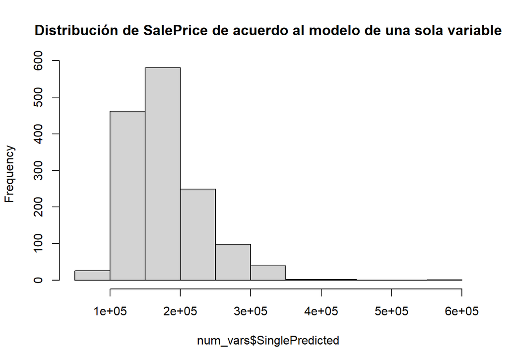

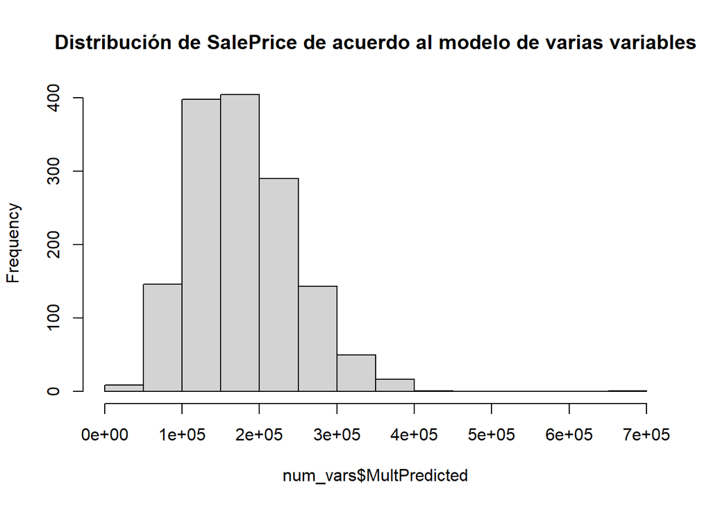

Con respecto a este estudio nuestras recomendaciones es buscar nuevas fuentes de información si se desea tener un modelo con mayor accuracy de predicción.